# Best K for clustering

```r
library(purrr)
#install.packages("ScalesList")
library(tidyr)
library(ggplot2)
library(SOMbrero)
```

# Clustering

- SOM Brero model training is completed with optimized parameter.
- Model has code vectors/ prototypes which represent the input data.
- Code vectore needs to be clustered to get insights.
- Common question in clustering is, how to choose best K?
- Here different measures are used to understand the impact of different K values.

```r
# --------------------------------- --------------------------------#
#                 AIC and BIC                                       #
#                 For best K evaluation                             #
# --------------------------------- --------------------------------#


df_prototypes <- FS1_T0_Brero$prototypes

# Common dataframe to capture the results.
df_k_cols<- c("AIC", "BIC", "K")
df_k <- data.frame(matrix(ncol = length(df_k_cols),nrow = 0))
colnames(df_k) <- df_k_cols
```

# AIC and BIC calculation

- Probabilistic statistical measures.
- AIC : Akaike information criterion
- BIC : Bayesian information criterion
- Advantage over elbow method : calculated AIC/ BIC value includes a penalty for the number of clusters used .
- AIC penalizes less to complex models when compared with BIC.This shows high predictive accuracy. (P et al. 2017)
- Lower values of AIC and BIC indicate the model is more likely the best or accurate one.

## *Method 1* : User defined function

- The AIC and BIC formulas were used to create user defined method/function.

```r
# https://rdrr.io/rforge/kmeansstep/man/kmeansBIC.html
# https://rdrr.io/rforge/kmeansstep/man/kmeansAIC.html

# Function for AIC and BIC calculation
information_criteron_functn <- function(k_fit){
  m = ncol(k_fit$centers)
  n = length(k_fit$cluster)
  k = nrow(k_fit$centers)
  D = k_fit$tot.withinss
  return(data.frame(AIC = D + 2*m*k,
                    BIC = D + log(n)*m*k,
                    K= k) )
}
```

- Iterate over K values and capture the AIC and BIC values for each K.

```r
#Clear old records
df_k <-df_k[0,]

k_max=nrow(df_prototypes)-1

for (i in 2:k_max) {
  cluster <- kmeans(x = df_prototypes, i)
  temp_df_k <- information_criteron_functn(cluster)
  df_k <- rbind(df_k, temp_df_k)
}
```

### Store the result in csv

```r
write.table(df_k, "D:\\Fs1_AIC_BIC_onPrototype.csv", sep=",", row.names=FALSE, quote=FALSE)
```

```r
df_k <- read.csv("D:\\Fs1_AIC_BIC_onPrototype.csv")
```

- Visualization of AIC and BIC values

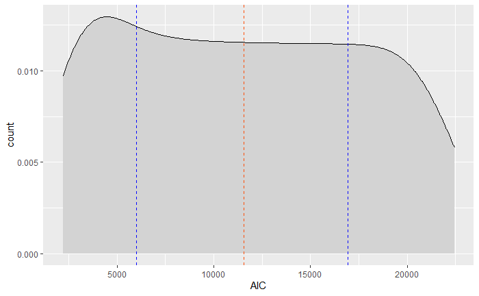

```r
# Density plot for AIC
gg_AIC <- ggplot(df_k, aes(x = AIC))
gg_AIC + geom_density(aes(y = ..count..), fill = "lightgray") +
  geom_vline(aes(xintercept = mean(AIC),),
             linetype = "dashed", size = 0.6,
             color = "#FC4E07")+
  geom_vline(aes(xintercept = quantile(AIC)[2],),
             linetype = "dashed", size = 0.6,
             color = "blue")+
  geom_vline(aes(xintercept = quantile(AIC)[4],),
             linetype = "dashed", size = 0.6,
             color = "blue")
```

[figure not shown]

```r
# Density plot for BIC
gg_BIC <- ggplot(df_k, aes(x = BIC))
gg_BIC + geom_density(aes(y = ..count..), fill = "lightgray") +
  geom_vline(aes(xintercept = mean(BIC),),
             linetype = "dashed", size = 0.6,
             color = "#FC4E07")+
  geom_vline(aes(xintercept = quantile(BIC)[2],),
             linetype = "dashed", size = 0.6,
             color = "blue")+
  geom_vline(aes(xintercept = quantile(BIC)[4],),
             linetype = "dashed", size = 0.6,
             color = "blue")
```

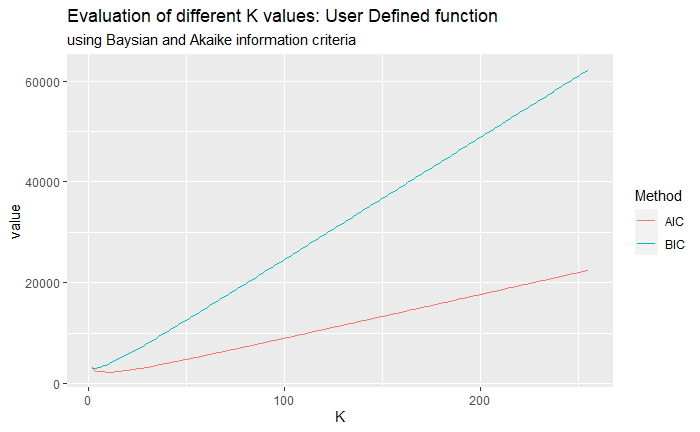

```r
#Plot AIC and BIC in graph
#library(purrr)
#library(tidyr)
#library(ggplot2)

p_k <- df_k %>%
  gather(Method,value, AIC, BIC) %>%
  ggplot(aes(x=K, y=value, colour=Method)) +
  geom_line()

p_k <- p_k + labs(title = "Evaluation of different K values: User Defined function", subtitle = "using Baysian and Akaike information criteria")
p_k
```

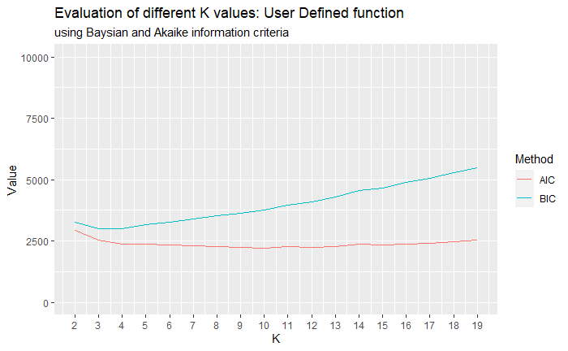

```r
p_k <- df_k %>%
  gather(Method,value, AIC, BIC) %>%
  ggplot(aes(x=K, y=value, colour=Method)) +
  geom_line() + scale_y_continuous(name="Value", limits=c(0, 10000))+scale_x_continuous(labels=as.character(df_k$K),breaks=df_k$K, limits = c(2,19))

p_k <- p_k + labs(title = "Evaluation of different K values: User Defined function", subtitle = "using Baysian and Akaike information criteria")

p_k
```

```r
summary(df_k)
```

```
      AIC             BIC              K
 Min.   : 2206   Min.   : 2989   Min.   :  2.00
 1st Qu.: 6000   1st Qu.:16178   1st Qu.: 65.25
 Median :11420   Median :31464   Median :128.50
 Mean   :11560   Mean   :31604   Mean   :128.50
 3rd Qu.:16919   3rd Qu.:46830   3rd Qu.:191.75
 Max.   :22441   Max.   :62217   Max.   :255.00
```

```r
df_k[df_k$AIC== min(df_k$AIC),] # K=9
```

|  | AIC | BIC | K |
| --- | --- | --- | --- |
| 9 | 2205.982 | 3765.86 | 10 |

```r
df_k[df_k$BIC== min(df_k$BIC),] # K=3
```

|  | AIC | BIC | K |
| --- | --- | --- | --- |
| 3 | 2365.198 | 2989.149 | 4 |

*Good range* * if we see range of min AIC and min BIC, K=3,4,9,10,12 yields the best result.

```r
min_AIC =min(df_k$AIC)
min_BIC =min(df_k$BIC)

df_k %>% filter(between(AIC,(min_AIC-35),min_AIC+35))
```

| AIC | BIC | K |
| --- | --- | --- |
| 2231.641 | 3635.532 | 9 |
| 2205.982 | 3765.860 | 10 |
| 2234.153 | 4106.006 | 12 |

```r
df_k %>% filter(between(BIC,(min_BIC-35),min_BIC+35))
```

| AIC | BIC | K |
| --- | --- | --- |
| 2526.423 | 2994.386 | 3 |
| 2365.198 | 2989.149 | 4 |

```r
NA
NA
```

## *Method 2* : Package ClusterR

- Package ClusterR has inbuilt method for getting optimal K values as per criteria.
- Various criterias can be selected for evaluation.
- AIC and BIC used in my analysis.
- method Optimal_Clusters_KMeans() used.

```r
#install.packages("ClusterR")
#library(ClusterR)

#Get AIC values for K= [2,254]
opt_km = Optimal_Clusters_KMeans(rescale_df, max_clusters = k_max-1, criterion = "AIC",
                                 plot_clusters = FALSE)
#plot(opt_km, xlab = "K clusters", ylab = "AIC values", xlim = c(2,50), ylim = c(50,5000))
#min(opt_km) # 2220.408

#Get BIC values for K= [2,254]
opt_BIC_km = Optimal_Clusters_KMeans(rescale_df, max_clusters = k_max-1, criterion = "BIC",
                                 plot_clusters = FALSE)

# Combine the results
#df_k_cols<- c("AIC", "BIC", "K")

df_k_byPkg <- data.frame(matrix(ncol = length(df_k_cols),nrow = 0))

df_k_byPkg <- df_k_byPkg[0,]
df_k_byPkg<-cbind(opt_km,opt_BIC_km)
df_k_byPkg<-as.data.frame(df_k_byPkg)
head(df_k_byPkg)

#library("dplyr") # or library("tidyverse")

df_k_byPkg$K  <- 1:nrow(df_k_byPkg)

colnames(df_k_byPkg) <- df_k_cols
```

```r
pkg_p<- df_k_byPkg %>%
  gather(Method,value, AIC, BIC) %>%
  ggplot(aes(x=K, y=value, colour=Method)) +
  geom_line()

pkg_p<-pkg_p+ labs(title = "Evaluation of different K values: ClusterR package ", subtitle = "using Baysian and Akaike information criteria")
pkg_p+scale_x_continuous(labels=as.character(df_k$K),breaks=df_k$K)+scale_y_continuous(labels=as.character(y),breaks=y)

pkg_p


# More clear scales
pkg_p_1 <- df_k_byPkg %>%
  gather(Method,value, AIC, BIC) %>%
  ggplot(aes(x=K, y=value, colour=Method)) +
  geom_line() + scale_y_continuous(name="Value", limits=c(0, 10000))+scale_x_continuous(labels=as.character(df_k$K),breaks=df_k$K, limits = c(2,19))

pkg_p_1 <- pkg_p_1 + labs(title = "Evaluation of different K values:  ClusterR package", subtitle = "using Baysian and Akaike information criteria")

pkg_p_1
```

[output not shown]

```r
df_k_byPkg[df_k_byPkg$AIC==min(df_k_byPkg$AIC), ] # min at k=8
df_k_byPkg[df_k_byPkg$BIC==min(df_k_byPkg$BIC), ] # min at k=4
```

[output not shown]

# Combined results

[output not shown]

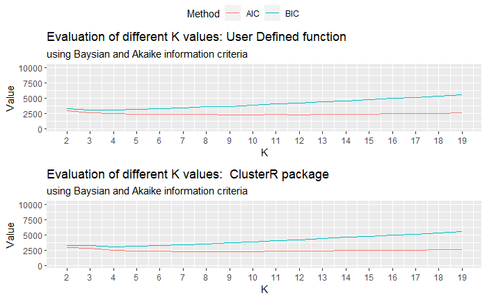

```r
#install.packages("cellranger")
library(ggpubr)
ggarrange(p_k,pkg_p_1, nrow = 2, common.legend = TRUE)
```

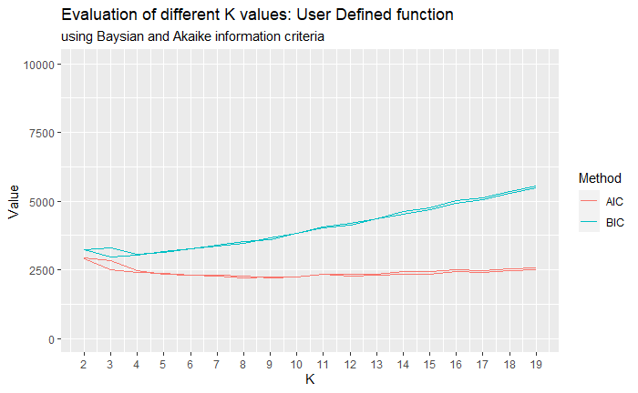

```r
gather_df <- df_k_byPkg %>%  gather(Method,value, AIC, BIC)
combine_p <- p_k + geom_line(data = gather_df)

combine_p
```

```r
print(paste0("User defined method result" ))
print(paste0("Min AIC=",min(df_k$AIC)," at K = ",df_k[df_k$AIC== min(df_k$AIC),3] ))
print(paste0("Min BIC=",min(df_k$BIC)," at K = ",df_k[df_k$BIC== min(df_k$BIC),3] ))
print(paste0("ClusterR package method result" ))
print(paste0("Min AIC=",min(df_k_byPkg$AIC)," at K = ",df_k_byPkg[df_k_byPkg$AIC== min(df_k_byPkg$AIC),3] ))
print(paste0("Min BIC=",min(df_k_byPkg$BIC)," at K = ",df_k_byPkg[df_k_byPkg$BIC== min(df_k_byPkg$BIC),3] ))
```

[output not shown]

# Best K values

- More analysis done with K values = 3,4,8,9

```r
best_k_values <- c(3,4,8,9)
```